# MEML_PS02_Optimization_Soln

**Machine Learning for Mechanical Engineering**  
**Solution of Opimization**

Prof. Seungchul Lee  
http://iailab.kaist.ac.kr/  
Industrial AI Lab at KAIST

- For your handwritten solutions, please scan or take a picture of them. Alternatively, you can write them in markdown if you prefer.
- Only .ipynb files will be graded for your code.
  - Ensure that your NAME and student ID are included in your .ipynb files. ex) SeungchulLee_20241234_HW01.ipynb
- Compress all the files into a single .zip file.
  - In the .zip file's name, include your NAME and student ID. ex) SeungchulLee_20241234_HW01.zip
  - Submit this .zip file on KLMS
- Do not submit a printed version of your code, as it will not be graded.

# Problem 2

Find solution $D$ of the optimization problem with the following objective function and constraints. Here, $\lVert \cdot \rVert_2$ denotes the Euclidean norm (or distance).

(Hint: you do not have to find the optimal value of $Z$)

$$\begin{align*} D= \min_Z \;\; & \lVert X_1 - Z \rVert_2 + \lVert X_2 - Z \rVert_2 \\ \\ \text{subject to} \; & Z \in \text{span} \{V_1, V_2\} \end{align*}$$

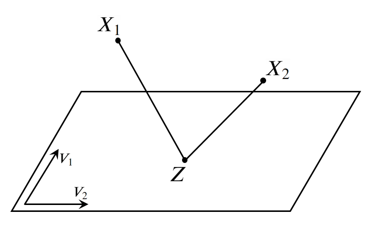

## Solution 2

$D^*$ is the shortest distance from $X_1$ to $X_2$ via $Z$ on the spanned hyperplane. The shortest line is the straight line from $X_1$ and $Y$ which is mirrored reflection of $X_2$ with respect to the hyperplane.

$$ \begin{align*} D^* &=\lVert MX_1 - X_2\rVert\\ &= \lVert X_1 - MX_2 \rVert \\ & = \lVert X_1 - \left( 2V \left(V^TV \right)^{-1}V^T-I\right)X_2\rVert \end{align*} $$

where $M$ is mirror transformation and $V = [V_1 \; V_2]$

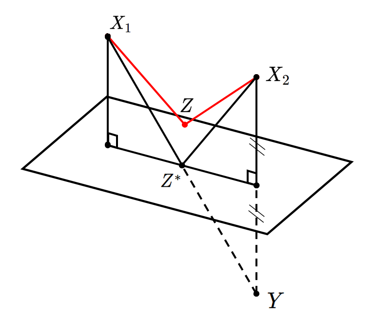

# Problem 3

(a) Find the solution by taking derivatives of the following objective function:

$$\min_{x} \,\,\, (2x_1 - 1)^2 + (-x_1 + x_2)^2 + (2x_2 +1)^2$$

(b) Formulate the above corresponding least-squares problem (i.e., find one of possible $A$ and $b$), and solve it using cvxpy.

$$\min_{x} \, \lVert Ax - b\rVert_2 ^2$$

```python
# write your code here
#
```

## Solution 3

(a)

Let $$ \begin{align*} f &= (2x_1 - 1)^2 + (-x_1 + x_2)^2 + (2x_2 +1)^2 \\ \\ \frac{\partial f}{\partial x_1} &= 2(2x_1 - 1)2 + (-x_1 + x_2)(-1) = 10x_1 - 2x_2 - 4 = 0 \\ \frac{\partial f}{\partial x_2} &= 2(-x_1 + x_2) + 2(2x_2 + 1)2 = -2x_1 + 10x_2 + 4 = 0 \\ \end{align*} $$

$$ \begin{align*} \begin{bmatrix} 10 & -2 \\ -2 & 10 \end{bmatrix} \begin{bmatrix} x_1 \\ x_2 \end{bmatrix} + \begin{bmatrix} -4 \\ 4 \end{bmatrix} &= 0 \\\\ \begin{bmatrix} x_1 \\ x_2 \end{bmatrix} &= \begin{bmatrix} 10 & -2 \\ -2 & -10 \end{bmatrix}^{-1} \begin{bmatrix} 4 \\ -4 \end{bmatrix} \\\\ &= \frac{1}{96}\begin{bmatrix} 10 & 2 \\ 2 & 10 \end{bmatrix} \begin{bmatrix} 4 \\ -4 \end{bmatrix} =\frac{1}{3}\begin{bmatrix} 1 \\ -1 \end{bmatrix} \end{align*} $$

$$ \text{Thus} \ x_1 = \frac{1}{3} \quad \text{and}\quad x_2 = -\frac{1}{3} $$

(b)

$$ A = \begin{bmatrix} 2 & 0\\ -1 & 1\\ 0 & 2\end{bmatrix} ,\quad b = \begin{bmatrix} 1\\ 0\\ -1\end{bmatrix} $$

```python
import numpy as np
import cvxpy as cvx

x = cvx.Variable([2, 1])
A = np.array([[2, 0], [-1, 1], [0, 2]])
b = np.array([[1], [0], [-1]])
objective = cvx.Minimize(cvx.norm(A@x - b, 2))
prob = cvx.Problem(objective)
result = prob.solve()

print(x.value)
print(result**2)
```

```
[[ 0.33333333]
 [-0.33333333]]
0.6666666666666666
```

# Problem 5

In this problem we use least-squares to fit a circle to given points $(u_i, v_i)$ in a plane, as shown in the figure.

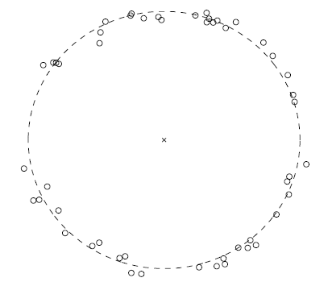

We use $(u_c, v_c)$ to denote the center of the circle and $R$ for its radius. A point $(u,v)$ is on the circle if $(u-u_c)^2 + (v-v_c)^2 = R^2$. We can therefore formulate the fitting problem as

$$\text{minimize } \sum_{i=1}^{m} \left( (u_i-u_c)^2 + (v_i-v_c)^2 - R^2 \right)^2$$

With variables $v_c, u_c$, and $R$.

(a) Show that this can be written as a linear least-squares problem if we make a change of variables and use as variables $u_c, v_c$ and $\omega = u_c^2 + v_c^2 -R^2$.

(b) Find $A, b$, and $x$ in the equivalent linear least-squares formulations.

## Solution 5

(a)

Let

$$ \begin{align*} f = (u_i-u_c)^2 + (v_i-v_c)^2 - R^2\\ \end{align*} $$

To minimize $\sum_{i=1}^{m} \left( (u_i-u_c)^2 + (v_i-v_c)^2 - R^2 \right)^2$, $(u_i, v_i)$ has to exist on the circle above, such that $f=0$.

Thus we can express $f$ as

$$ \begin{align*} f &=u_i^2 - 2u_iu_c + u_c^2 + v_i^2 - 2v_iv_c + v_c^2 - R^2\\ &= (u_i^2 + v_i^2) + (-2u_iu_c - 2v_iv_c) + (u_c^2 + v_c^2 - R^2) \\ & = (u_i^2 + v_i^2) + (-2u_iu_c - 2v_iv_c) + w = 0 \end{align*} $$

Hence, a change of variables to $u_c, v_c,$ and $w$ allows us to rewrite this problem as

$$\text{minimize} \sum_{i=1}^{m} \left( (u_i^2 + v_i^2) + (-2u_iu_c - 2v_iv_c) + w \right)^2$$

(b)

Formulating the problem in matrix form,

$$ \begin{align*} \begin{bmatrix} -2u_1 & -2v_1 & 1\\ -2u_2 & -2v_2 & 1\\ \vdots &\vdots &\vdots \\ -2u_m & -2v_m & 1 \end{bmatrix} \begin{bmatrix} u_c\\ v_c\\ w\end{bmatrix} = \begin{bmatrix} -u_1^2 - v_1^2\\ -u_2^2 - v_2^2\\ \vdots \\ -u_m^2 - v_2^m \end{bmatrix} \end{align*} $$

This gives us a linear form of $Ax = b$, where $A$ is a skinny matrix with a size of $m\times3$. Hence we can use the least-squares method to obtain the optimal $x^*$.

# Problem 7 (Steepest Descent Method)

Consider the following optimization problem:

$$ \begin{align*} \min \quad f(X) & = \frac{1}{2}X^TAX-b^TX \qquad (\text{where}\; A = A^T)\\ \end{align*} $$

Here, the steepest descent algorithm:

$$\begin{align*} &\text{Steepest Descent Algorithm} \; \\ &1 \;\;\; \text{Initialize at } X_i, \text{and set } i \leftarrow 0\\ &2 \;\;\; \text{At iteration } i\\ &3 \;\;\;\;\;\; d_i = \nabla f(X_i) = AX_i - b. \; \text{If} \; d_i = 0 \; \text{then stop.} \\ &4 \;\;\;\;\;\; \text{Choose step-size }\; \alpha_i = \frac{d_i^T d_i}{d_i^T A d_i} \\ &5 \;\;\;\;\;\; \text{Updated } X_{i+1} \leftarrow X_i - \alpha_i d_i \\ \end{align*}$$

(a) Show that $\alpha_i = \frac{d_i^T d_i}{d_i^T A d_i}$ is the best step-size.

(b) Determine the minimum of

$$f(x,y) = x^2+y^2+2x+4$$

$\quad \,$Use $X_0 = \begin{bmatrix} x_0 \\ y_0 \end{bmatrix} = \begin{bmatrix} 2 \\ 1 \end{bmatrix} $ as an initial point and the steepest descent algorithm by hands.

## Solution 7

(a)

We can fomulate this problem as

$$ \alpha = \underset{\alpha}{\arg\min} \; f(X_i-\alpha_id_i) $$

To solve this problem,

$$ \begin{align*} \frac{\partial f(X_i-\alpha_id_i)}{\partial \alpha} &= 0 \\ \frac{\partial f(X_i-\alpha_id_i)}{\partial \alpha} &= \frac{\partial f(X_i-\alpha_id_i)}{\partial \alpha} \times \frac{\partial f(X_i-\alpha_id_i)}{\partial (X_i-\alpha_id_i)}\\ &= d_i^T \times ( \nabla f(X_{i+1})) = -d_i \times (A(X_i-\alpha_id_i)-b) \\ \\ &= 0\\ \end{align*} $$

Therefore, $$ \alpha_i = \frac{d_i^T d_i}{d_i^T A d_i} $$

(b)

$$ \begin{align*} f(x,y) &= x^2+y^2+2x+4\\ \\ &= \frac{1}{2} \begin{bmatrix} x & y \end{bmatrix}\begin{bmatrix}2 & 0 \\ 0 & 2 \end{bmatrix}\begin{bmatrix} x \\ y \end{bmatrix} - \begin{bmatrix} -2 & 0 \end{bmatrix}\begin{bmatrix} x \\ y \end{bmatrix} + 4 \end{align*} $$

Then, this problem becomes a linear form of $Ax = b$

$$ A = \begin{bmatrix}2 & 0 \\ 0 & 2 \end{bmatrix},\quad X = \begin{bmatrix} x \\ y \end{bmatrix} , \quad b = \begin{bmatrix} -2 \\ 0 \end{bmatrix} $$
We can calculate $d_0 = \nabla f(X_0)$ and $\alpha_0$

$$ \begin{align*} d_0 &= AX_0-b = \begin{bmatrix}2 & 0 \\ 0 & 2 \end{bmatrix}\begin{bmatrix} 2 \\ 1 \end{bmatrix} - \begin{bmatrix} -2 \\ 0 \end{bmatrix} = \begin{bmatrix} 6 \\ 2 \end{bmatrix}\\ \\ \alpha_0 &= \frac{\begin{bmatrix} 6 & 2 \end{bmatrix}\begin{bmatrix} 6 \\ 2 \end{bmatrix}}{\begin{bmatrix} 6 & 2 \end{bmatrix}\begin{bmatrix}2 & 0 \\ 0 & 2 \end{bmatrix}\begin{bmatrix} 6 \\ 2 \end{bmatrix}} = \frac{1}{2} \end{align*} $$

Similarly, calculate $X_1$, $d_1$

$$ \begin{align*} X_1 &= \begin{bmatrix} 2 \\ 1 \end{bmatrix} - \frac{1}{2}\begin{bmatrix} 6 \\ 2 \end{bmatrix} = \begin{bmatrix} -1 \\ 0 \end{bmatrix} \\ \\ d_1 &= AX_1-b = \begin{bmatrix}2 & 0 \\ 0 & 2 \end{bmatrix}\begin{bmatrix} -1 \\ 0 \end{bmatrix} - \begin{bmatrix} -2 \\ 0 \end{bmatrix} = \begin{bmatrix} 0 \\ 0 \end{bmatrix} \implies \text{STOP!} \end{align*} $$

Therefore,

$$ X = \begin{bmatrix} -1 \\ 0 \end{bmatrix} $$

$$ \text{min} \; f(X) = 3 $$

# Problem 8

A linear programming is in a canonical form if it is of the form:

$$\begin{align*} \text{minimize} \quad &c^Tx\\ \text{subject to} \quad & Ax\leq b\\ \quad & \;\;\, x\geq 0\\ \quad & \;\;\, x\in S\\\\ \end{align*}$$

A linear programming is in a standard form if it is of the form:

$$\begin{align*} \text{minimize} \quad &c^Tx\\ \text{subject to} \quad & Ax = b\\ \quad & \;\;\, x\geq 0\\ \quad & \;\;\, x\in S\\\\ \end{align*}$$

(a) Show that a linear programming in a canonical form can be transformed to one in a standard form.

$$ \begin{align*} Ax \leq b, x\geq 0 \quad \implies \quad \begin{bmatrix} A & \mathbb{1} \end{bmatrix} \begin{bmatrix} x\\ \omega \end{bmatrix}=b,\quad \begin{bmatrix} x\\ \omega \end{bmatrix} \geq 0 \end{align*}$$

(hint) $\omega$ is a slack variable

## Solution 8

(a)

Let

$$ Ax \leq b \implies Ax-b \leq 0 $$

Next define a slack variable $w$

$$ \begin{align*} -w &= Ax - b \leq 0 \implies w \geq 0\\ -w &= Ax - b \implies Ax + w = b \implies \begin{bmatrix}A & \mathbb{1}\end{bmatrix}\begin{bmatrix}x\\ \omega \end{bmatrix}=b \;, \begin{bmatrix} x \\ w \end{bmatrix} \geq 0 \end{align*} $$

# Problem 9

Python provides the '[`linprog`](https://docs.scipy.org/doc/scipy/reference/generated/scipy.optimize.linprog.html)' function in the '`scipy.optimize`' module to solve linear programming problems in the following form.

$$ \begin{align*} \min \quad &c^Tx\\ \text{subject to} \quad &A_{ub}x \leq b_{ub}\\ &A_{eq}x = b_{eq}\\ & l \leq x \leq u \end{align*} $$

(a) Solve the following optimization problem using `linprog`

$$ \begin{align*} \max \quad & x_1 + x_2 \\\\ \text{subject to} \quad & 2x_1 + x_2 \leq 29 \\ & x_1 + 2x_2 \leq 25 \\ & x_1 \geq 2 \\ & x_2 \geq 5 \end{align*} $$

```python
import numpy as np
from scipy.optimize import linprog

# write your code here
#
```

## Solution

```python
## solution

import numpy as np
from scipy.optimize import linprog

c = np.matrix([[-1, -1]])
A_ub = np.matrix([[2, 1], [1, 2]])
b_ub = np.matrix([[29], [25]])
x0_bounds = (2, None)
x1_bounds = (5, None)

result = linprog(c, A_ub=A_ub, b_ub=b_ub, bounds = [x0_bounds, x1_bounds])

print(result)
```

```
        message: Optimization terminated successfully. (HiGHS Status 7: Optimal)
        success: True
         status: 0
            fun: -18.0
              x: [ 1.100e+01  7.000e+00]
            nit: 2
          lower:  residual: [ 9.000e+00  2.000e+00]
                 marginals: [ 0.000e+00  0.000e+00]
          upper:  residual: [       inf        inf]
                 marginals: [ 0.000e+00  0.000e+00]
          eqlin:  residual: []
                 marginals: []
        ineqlin:  residual: [ 0.000e+00  0.000e+00]
                 marginals: [-3.333e-01 -3.333e-01]
 mip_node_count: 0
 mip_dual_bound: 0.0
        mip_gap: 0.0
```

# Problem 10

(a) Show that the given constrained optimization problem can be transformed to the unconstrained optimization one (quadratic penalty method)

$$\begin{align*} \text{minimize} & \quad f(x) & \text{minimize} & \quad f(x) + \sum_{i=1}^{l} \gamma_i\{\max(0, g_i(x))\}^2 + \sum_{i=1}^{m} \mu_i \{h_i(x)\}^2\\ \text{subject to} & \quad g(x) \leq 0 \quad \qquad \implies \quad & \text{subject to} & \quad x \in S\\ &\quad h(x) = 0\\ &\quad x\in S \end{align*}$$

(b) Show that the given multi-objective optimization problem can be transformed to the single-objective optimization one (goal programming)

$$\begin{align*} \min \quad f_1(x), f_2(x), \cdots, f_m(x) \qquad \Longrightarrow \quad \qquad \min \quad &\beta \\\\ \text{subject to}\quad &f_1(x), f_2(x),\cdots, f_m(x)\leq \beta \end{align*}$$

## Solution 10

(a)

First, the constraint $g(x) \leq 0$ can be expressed as a penalty when $g(x) > 0 $

The penalty function is then formulated as the following:

$$ \text{max} \; (0, g_i(x))\\ $$

$$ \begin{align*} g_i(x) &< 0 \implies \text{max} \; (0, g_i(x)) = 0 \\ g_i(x) &= 0 \implies \text{max} \; (0, g_i(x)) = 0 = g_i(x) \\ g_i(x) &> 0 \implies \text{max} \; (0, g_i(x)) = g_i(x) \\ \end{align*} $$

Therefore, there is no penalty only when $g_i(x) \leq 0$

Second, we need to consider the constraint of $h(x) = 0$ \ lt can be expressed as a penalty when $h(x) ≠ 0$

Then, the second penalty function is formulated as following:

$$ (h(x))^2\\ $$

$$ \begin{align*} h(x) = 0 \implies (h(x))^2 = 0 \\ h(x) ≠ 0 \implies (h(x))^2 ≠ 0 \\ \end{align*} $$

Therefore, there is no penalty only when $h(x) = 0$.

(b)

We can rewrite the multi - objective function in single form using the smallest $\beta$ that satisfies all constraints $f_1(x) \leq \beta$ , $f_2(x) \leq \beta$ , $\cdots$.

The problem is then formulated as the following:

$$ \min \quad \beta \\ \text{subject to}\quad f_1(x), f_2(x),\cdots, f_m(x)\leq \beta $$

This means that we want to find the solution $x$ that results in the smallest value among $f_1(x), f_2(x), \cdots , f_m(x)$ while ensuring that neither of the objective function exceeds $\beta$.